# PackML HMI

Patrick Toohey

October 24, 2018

```r
library(ggplot2)

data <- read.csv("https://raw.githubusercontent.com/patricktoohey/packml-hmi/master/packexpo_evaluation/packml.hmi.csv")

levels.diffculty <- c(1, 2, 3, 4, 5)
labels.diffculty <- c("Very Difficult", "Difficult", "Normal", "Easy", "Very Easy")

levels.confidence <- c(1, 2, 3, 4, 5)
labels.confidence <- c("Not Confident at All", "Not Confident", "Normal", "Confident", "Very Confident")

levels.alarm <- c(1,2,3,4,5)
labels.alarm <- c("Bin Full", "Sealer Temp", "Material Low", "Connection Lost", "None of the Above")
```

# Demographics

This sections summarizes the general characteristics of the study’s sample population.

### Age:

Circle the range representing your age…

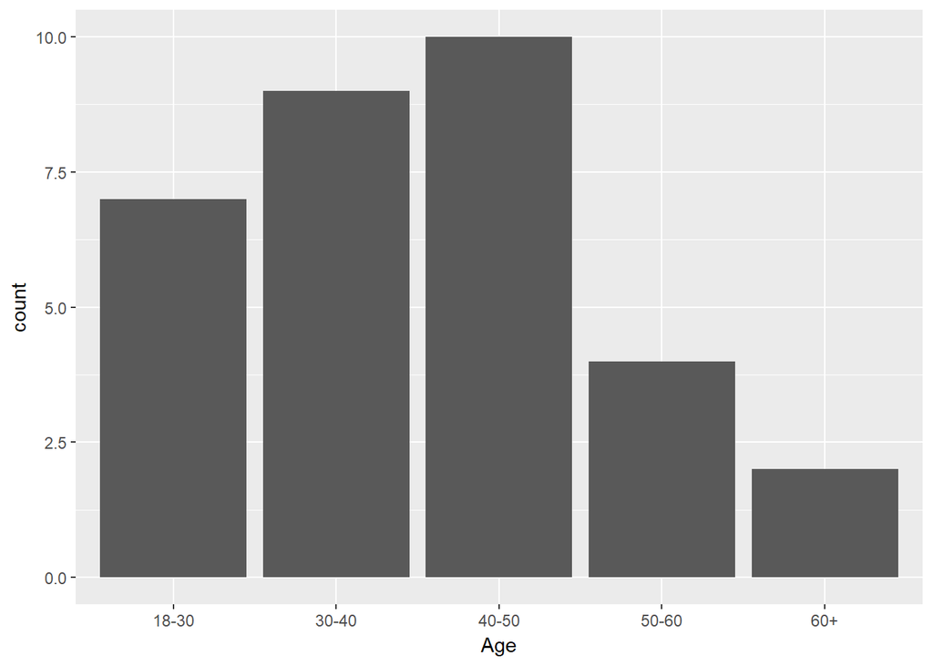

### Packaging HMI Experience:

Circle the description best representing your level of experience using packaging machine HMIs…

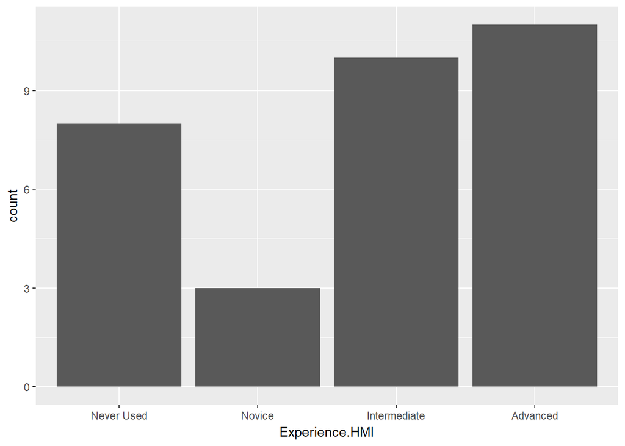

### Packaging Industry Experience:

Circle the description best representing your level of experience using packaging machine HMIs…

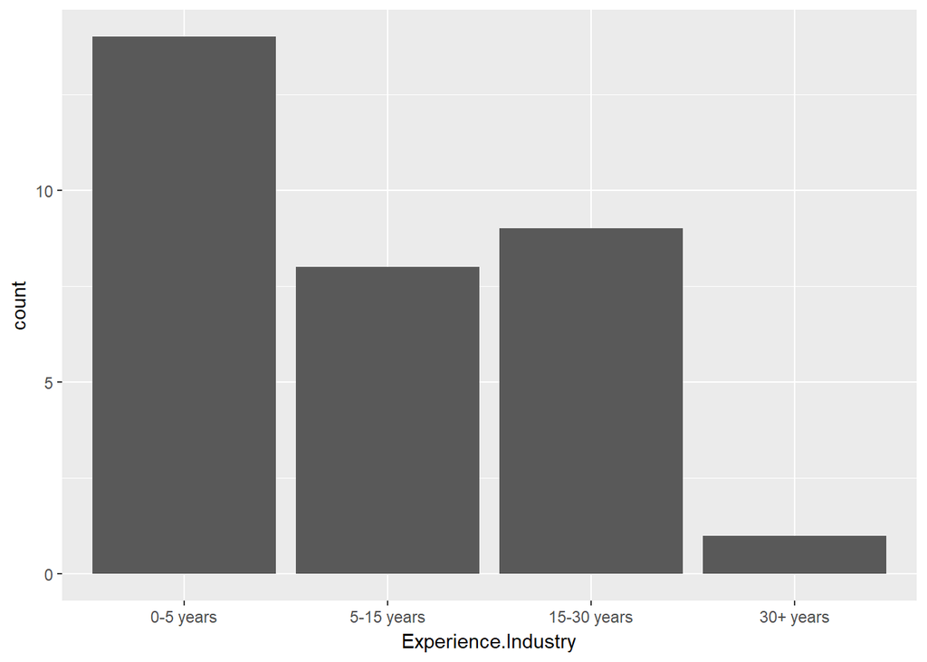

### Packaging Company Category:

Circle the description best representing your current company with respect to HMIs…

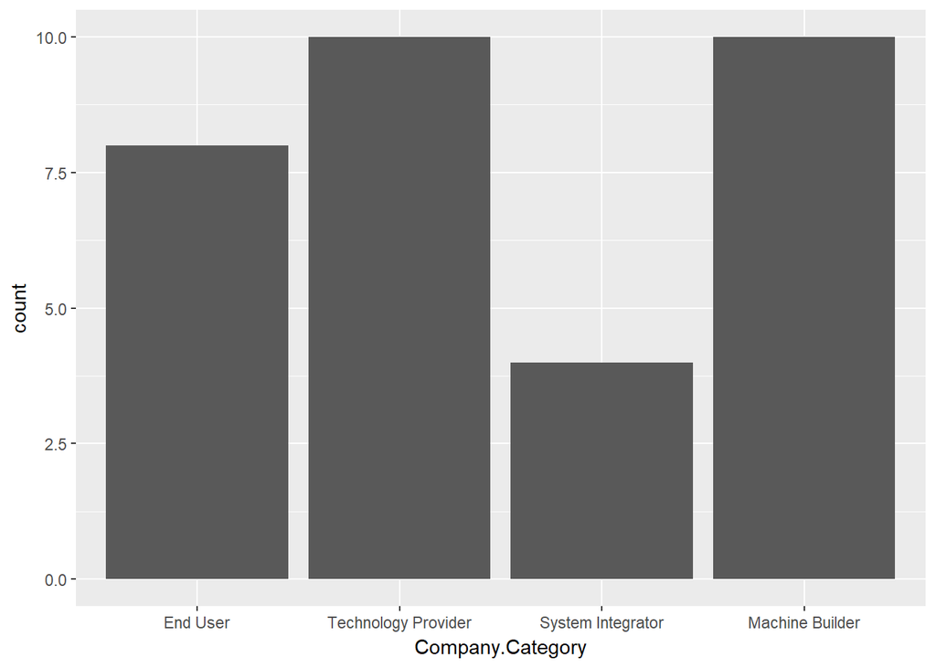

### Packaging HMI Role:

Circle the description best representing your current role with respect to equipment HMIs…

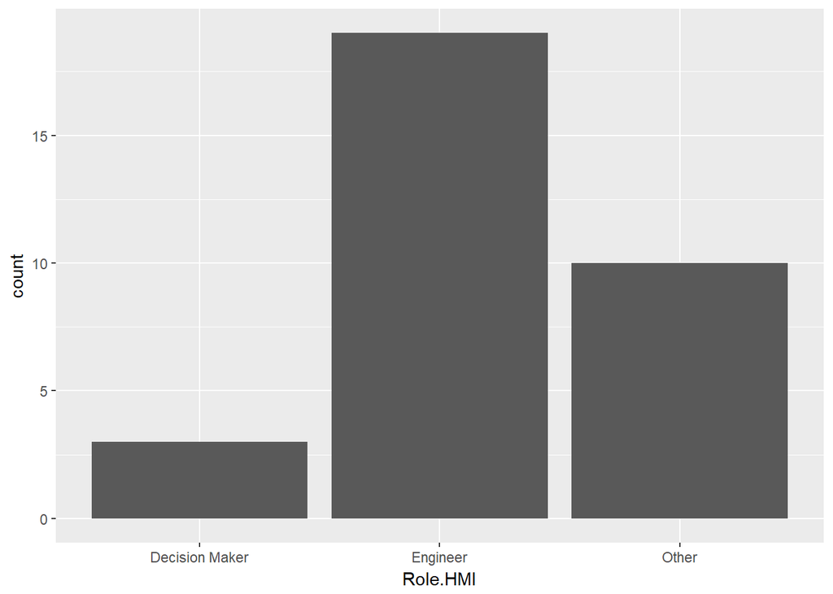

# Lenze HMI Evaluation

### Lenze Equipment Current State:

What is the numeric code representing the Current Equipment State?

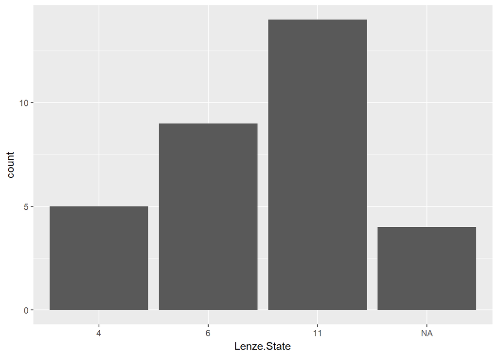

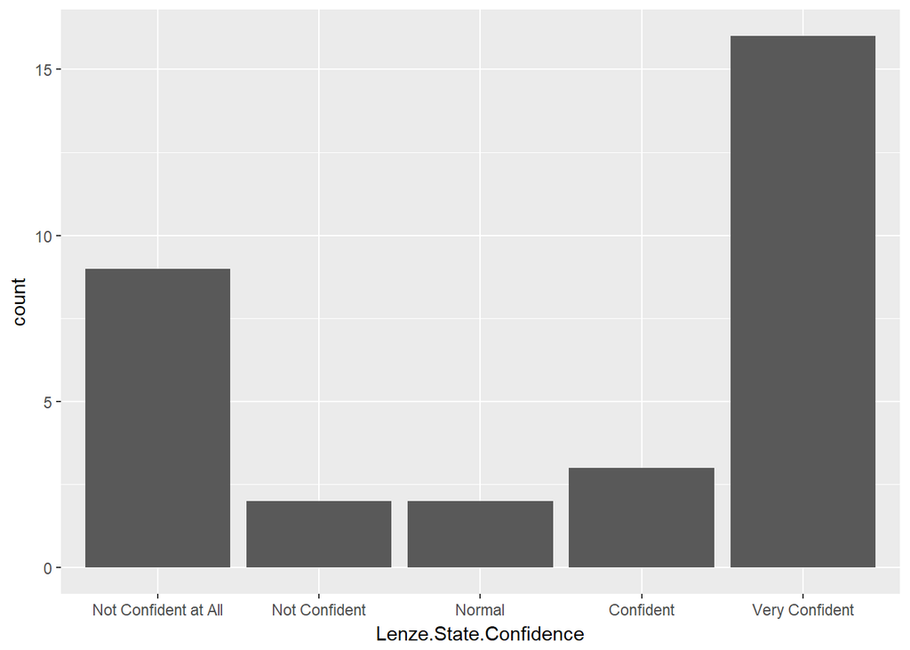

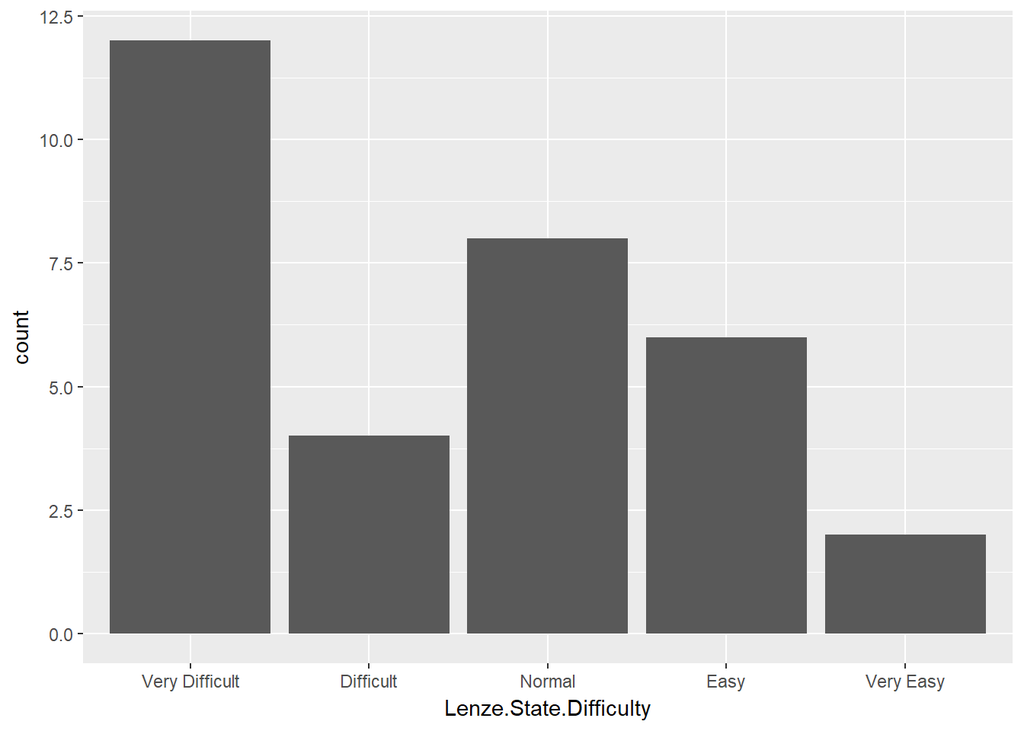

### Lenze IP Address:

What is the IP address of this Lenze device (i.e., Own IP Address)?

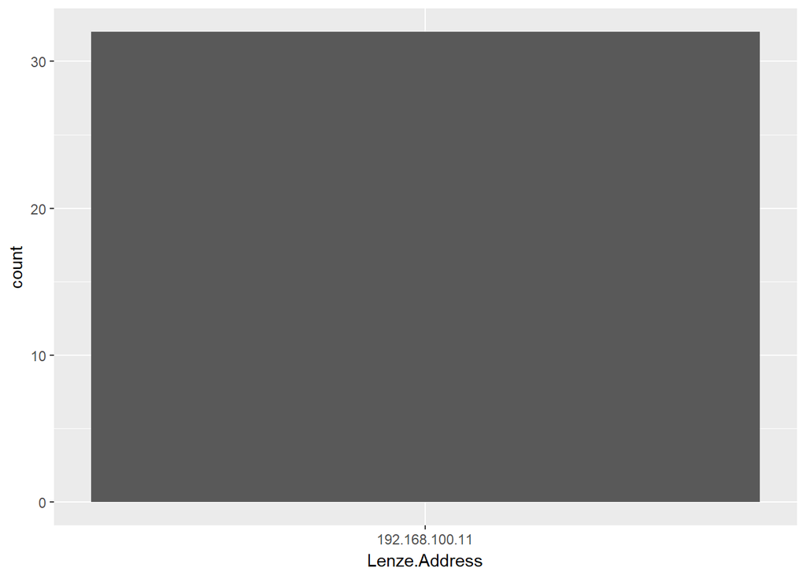

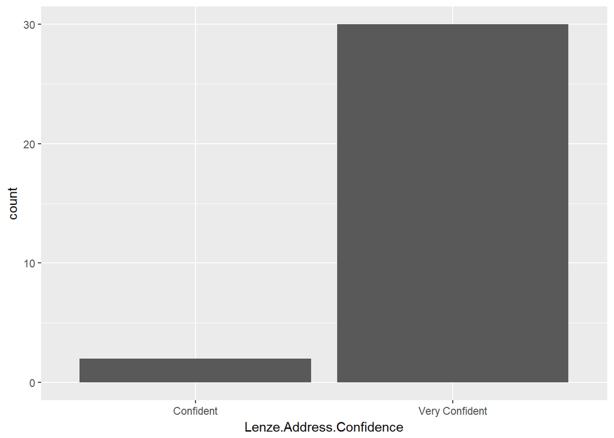

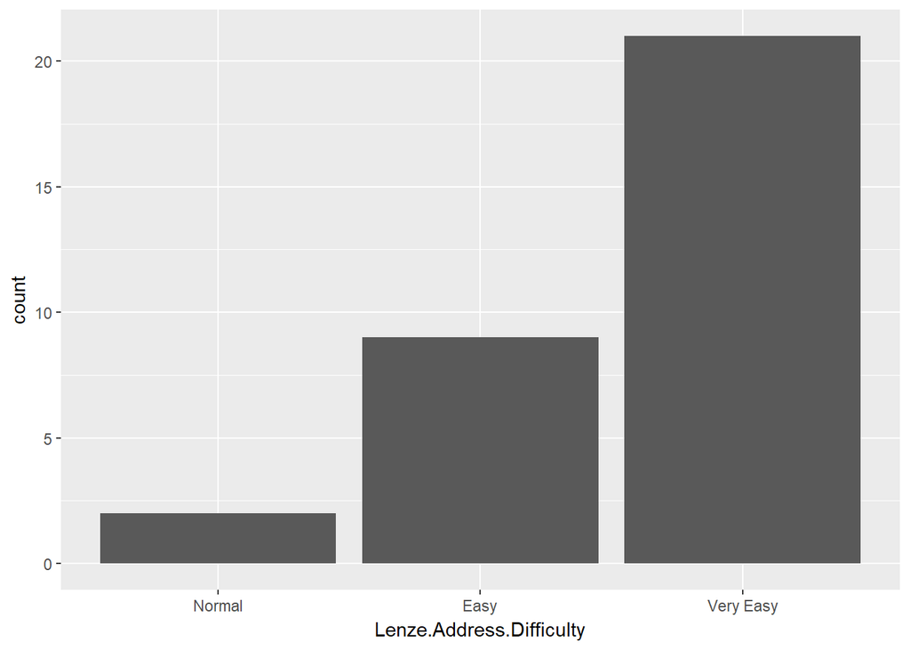

### Lenze Mode Current Time:

What is the current value of Mode Current Time?

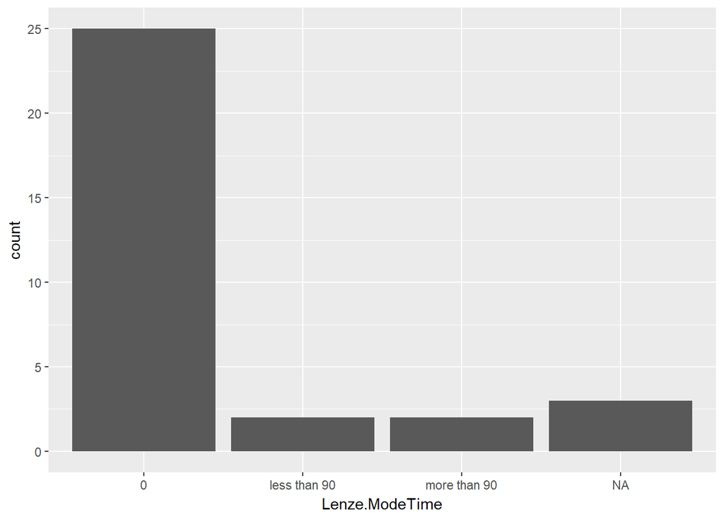

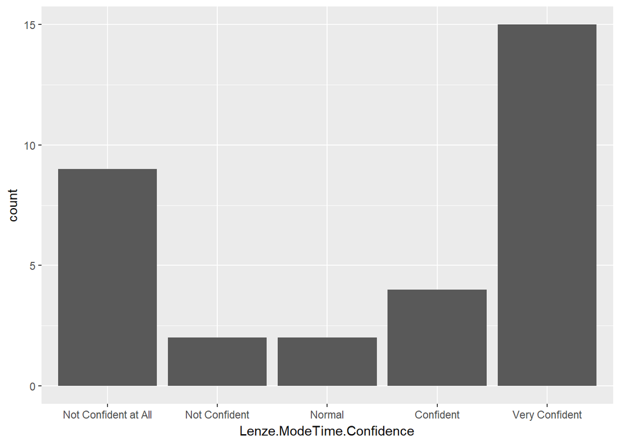

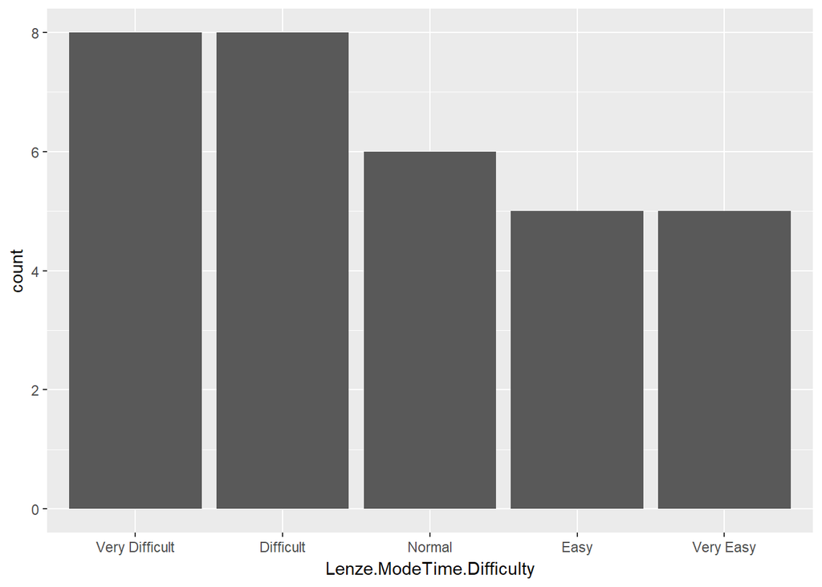

### Lenze Held Alarm:

Which of the following is the most recent alarm produced in the Held category?

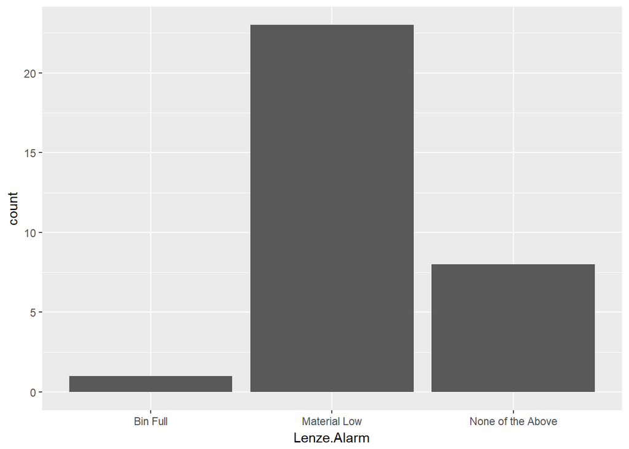

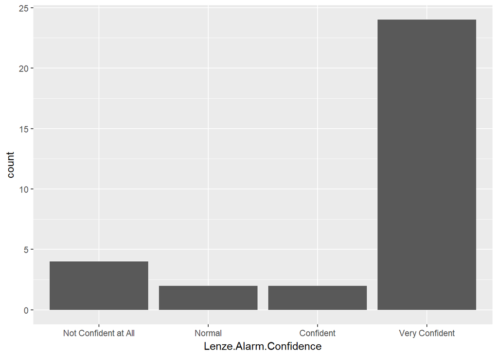

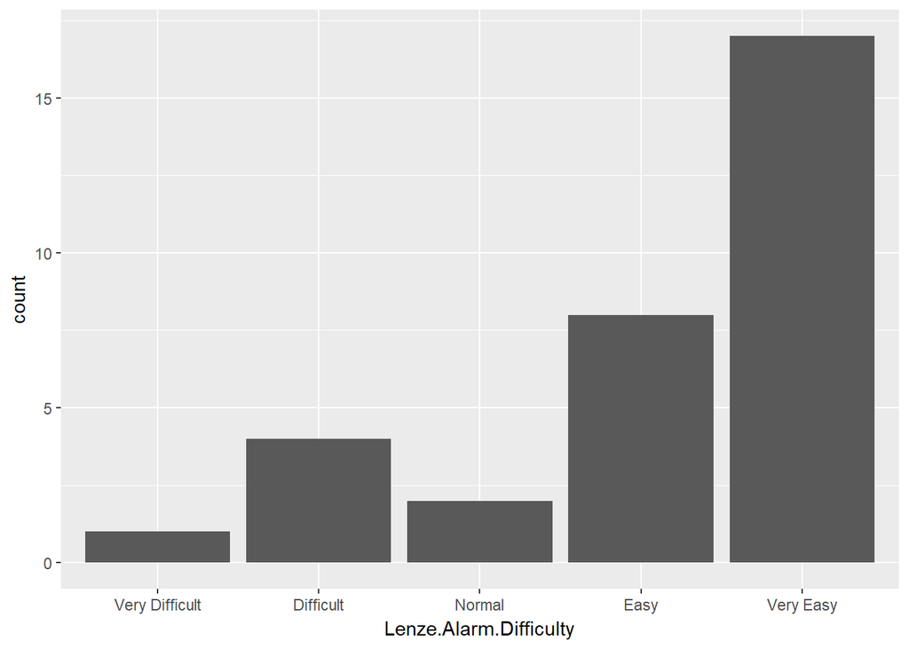

## Lenze Overall Difficulty

Overall, how difficult was the Lenze interface for the above tasks?

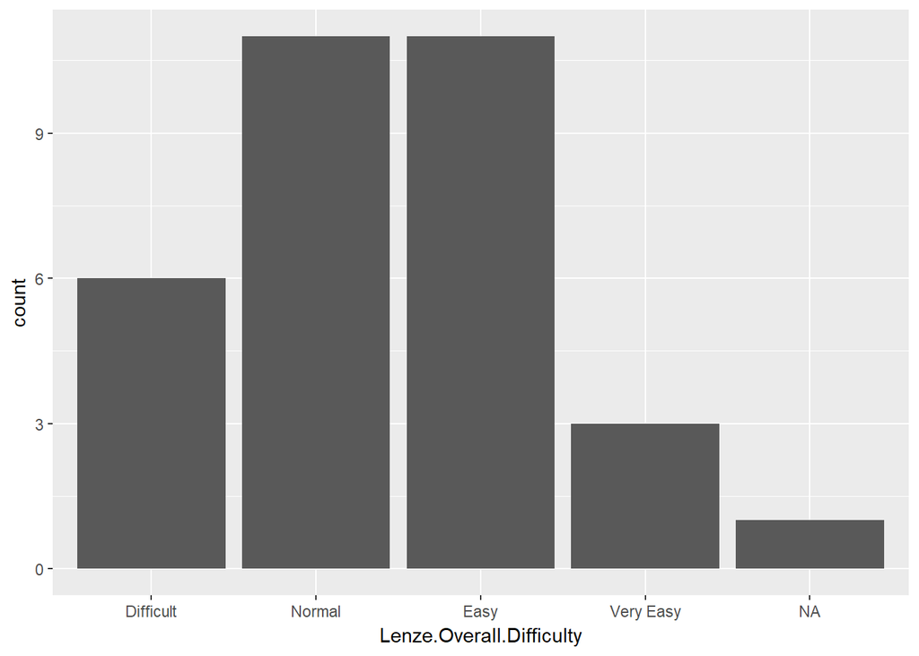

# Beckhoff / Nestle HMI Evaluation

### Beckhoff / Nestle Communicating Device Count:

What is the currently reported number of communicating devices?

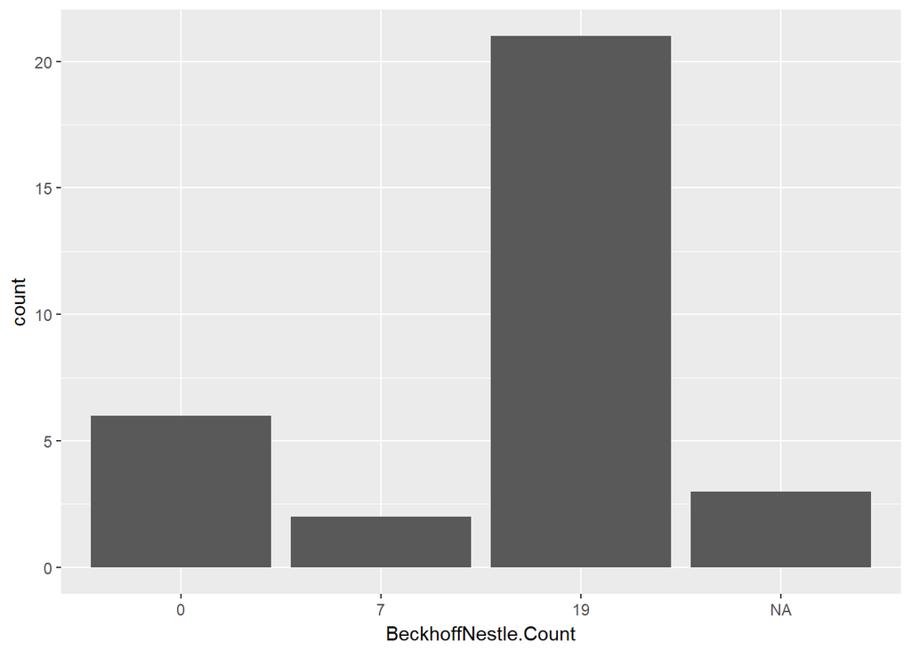

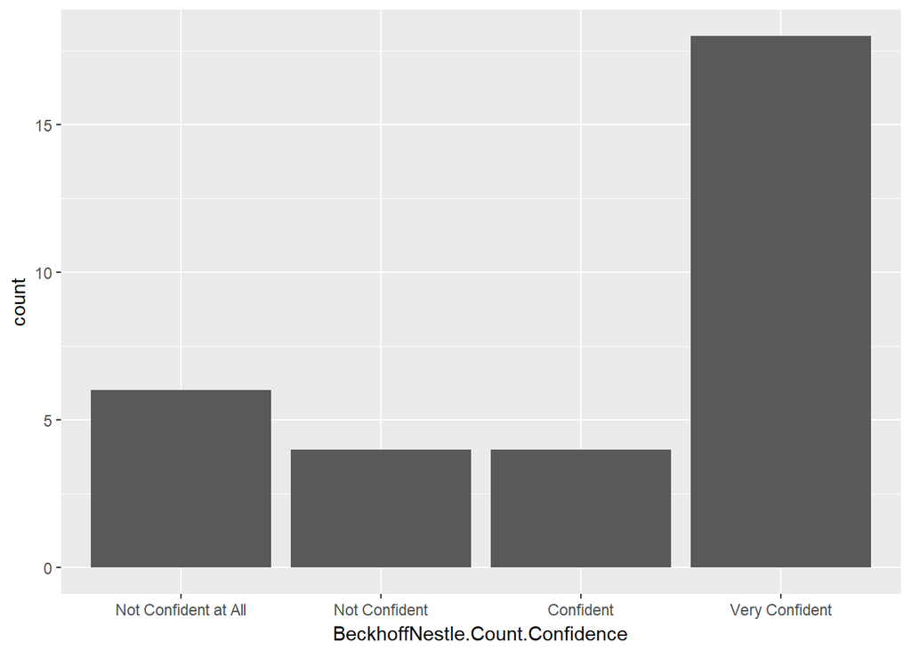

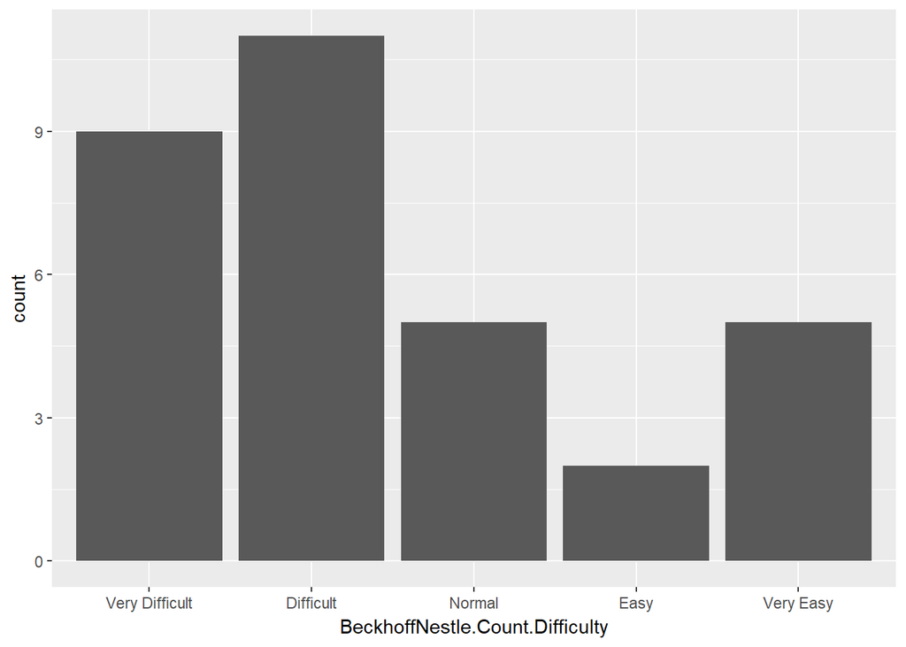

### Beckhoff / Nestle Sealer Temperature

What is the currently reported sealer temperature in degrees Celsius?

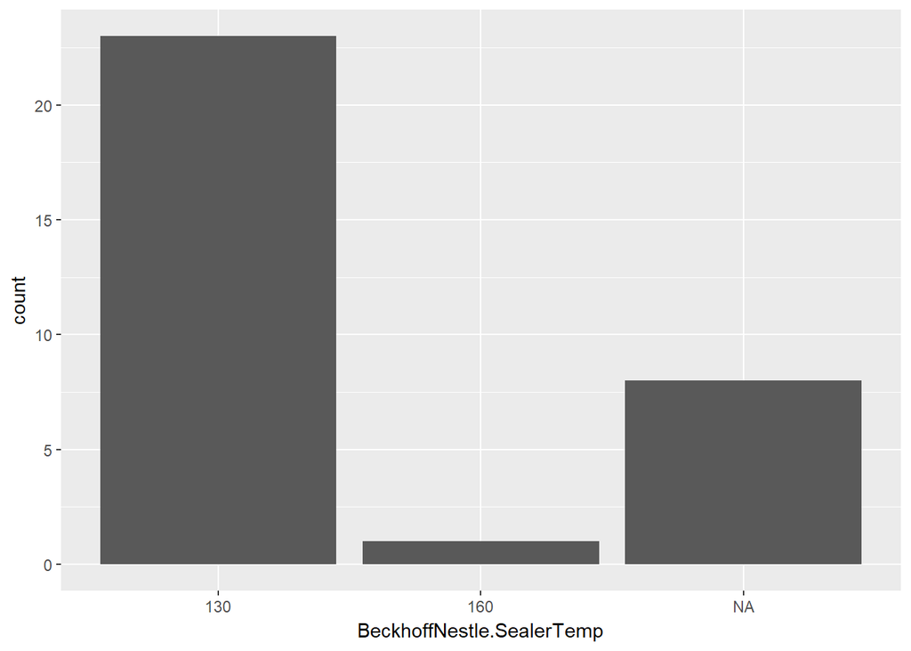

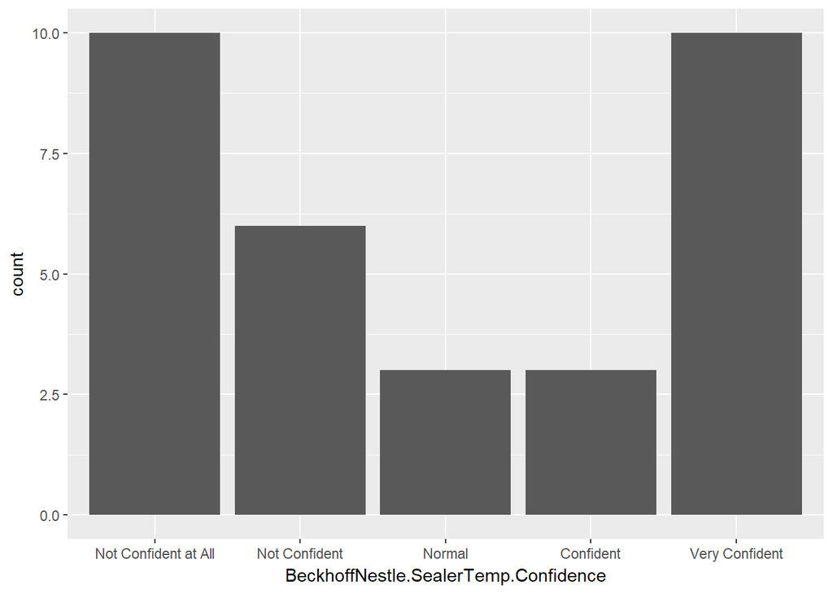

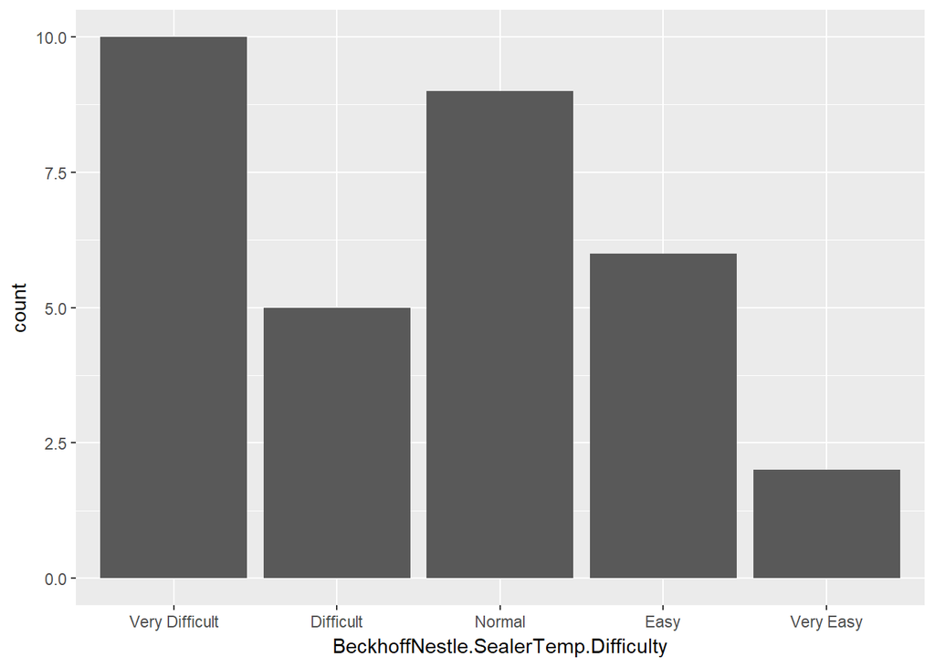

### Beckhoff / Nestle Bad Product Count:

What is the current Bad Product count?

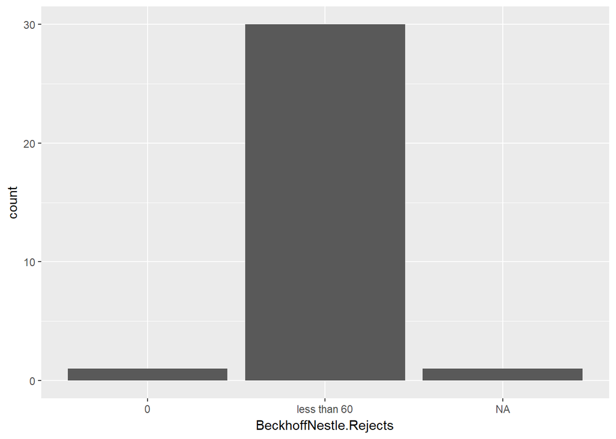

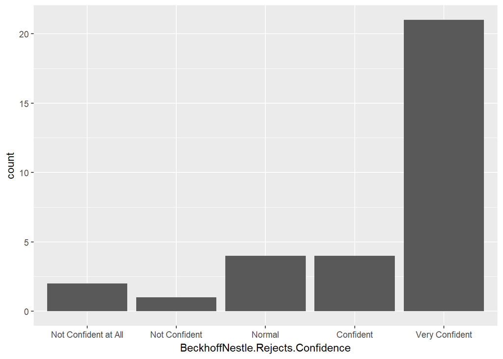

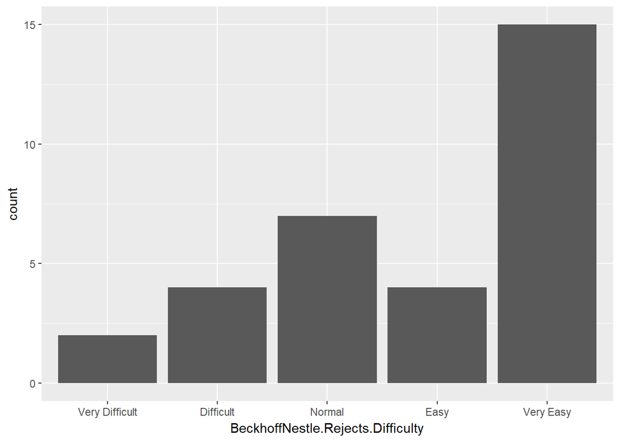

### Beckhoff / Nestle Alarm:

Which of the following is the most recent alarm?

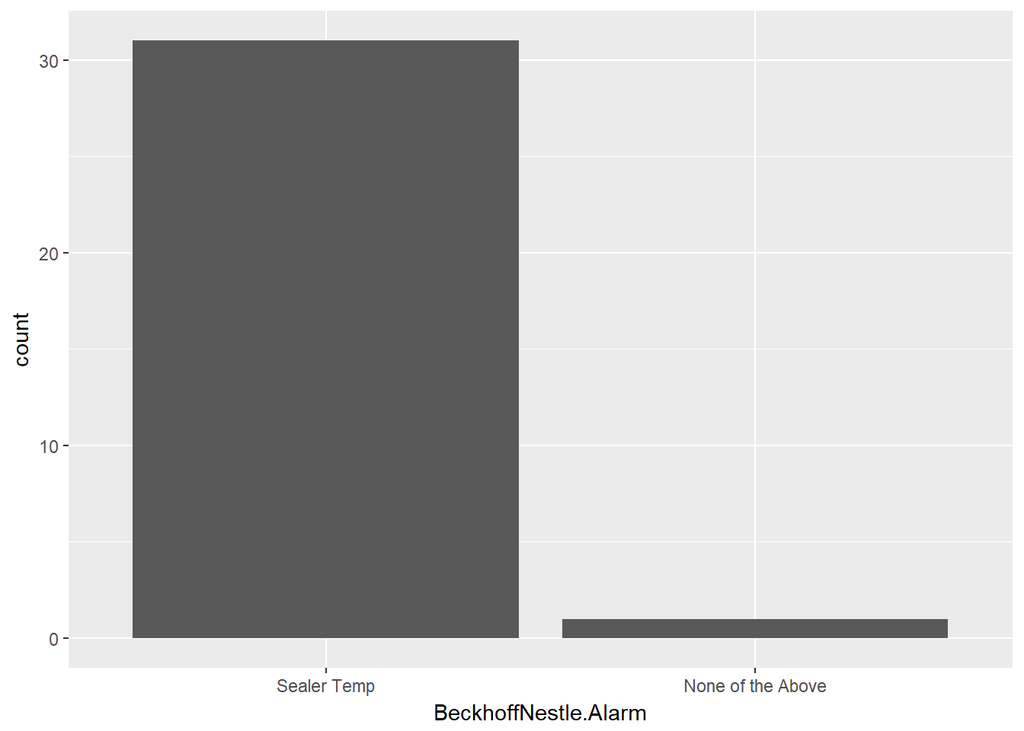

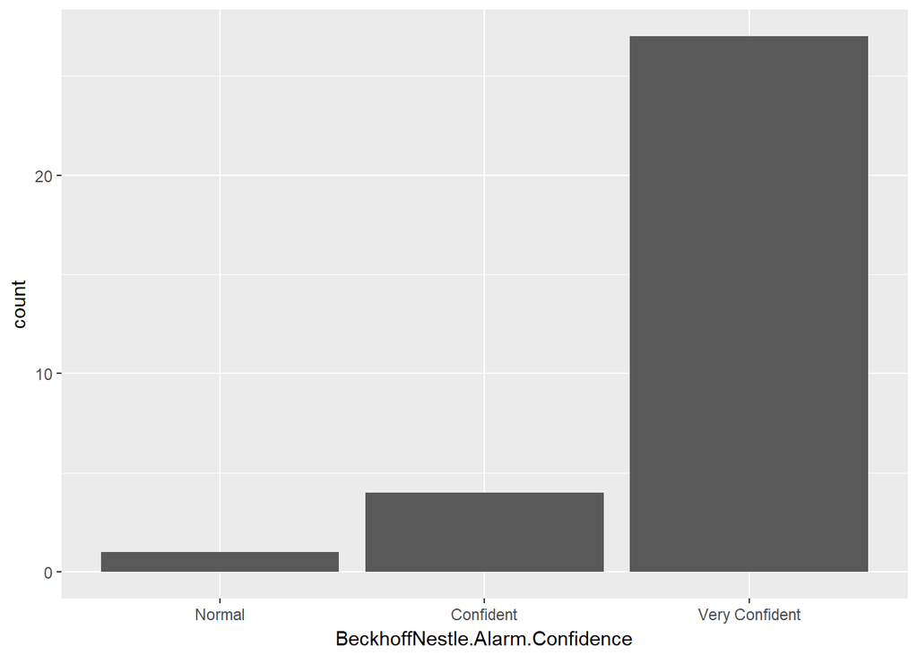

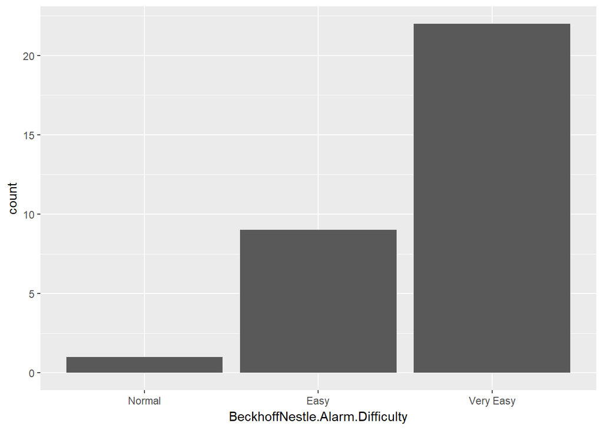

## Beckhoff / Nestle Overall Difficulty

Overall, how difficult was the Beckhoff/Nestle interface for the above tasks?

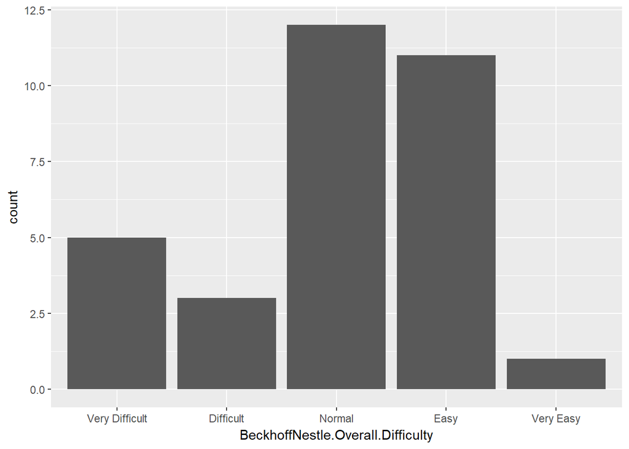